# Project 1: Frequent k-mers in the SARS-CoV-2 Genome

Author

Kasun Bebarende Guruge

# Abstract

This project explores algorithms for finding frequent k-mers in the SARS-CoV-2 genome. Two approaches are implemented: the **FrequentWords()** method by counting occurrences and the **BetterFrequentWords()** method using hashing. Additionally, the runtime of these algorithms is analyzed, and the most frequent k-mers for various values of k are reported. The biological significance of selected k-mers is also explored.

# Introduction

Frequent k-mers are an essential element of computational biology, helping to identify recurring patterns in genomic sequences. In this project, we use the SARS-CoV-2 genome to identify frequent k-mers using two different algorithms. We aim to compare the efficiency of these algorithms and understand the biological context of the most frequent k-mers found.

# Methods

## Implementing algorithms for finding frequent k-mers

### 1. Frequent Words by Counting

The **FrequentWords()** algorithm counts the occurrences of each k-mer in the genome using a brute-force approach. This algorithm uses the `PatternCount()` function to count k-mer occurrences.

```python
class BioinformaticsAlgorithms:

    # Method to count occurrences of a pattern in a given text
    def pattern_count(self, text, pattern):
        count = 0
        pattern_length = len(pattern)

        # Loop through the text and compare each substring with the pattern
        for i in range(len(text) - pattern_length + 1):
            if text[i:i + pattern_length] == pattern:
                count += 1

        return count

    # Method to find the most frequent k-mers (substrings of length k) in a given text with their counts
    def frequent_words(self, text, k):
        counts = {}

        # Loop through the text and calculate counts for each k-mer
        for i in range(len(text) - k + 1):
            pattern = text[i:i + k]
            counts[pattern] = self.pattern_count(text, pattern)

        # Find the maximum count
        max_count = max(counts.values())

        # Collect all patterns with the maximum count
        frequent_patterns_with_counts = {pattern: count for pattern, count in counts.items() if count == max_count}

        return frequent_patterns_with_counts

# Example usage
bio_algo = BioinformaticsAlgorithms()

# Example text and k value
text = "ACGTTGCATGTCGCATGATGCATGAGAGCT"
k = 4

# Finding the most frequent k-mers with their counts
frequent_kmers_with_counts = bio_algo.frequent_words(text, k)
print(frequent_kmers_with_counts)
```

```
{'GCAT': 3, 'CATG': 3}
```

### 2. Frequent Words by Hashing

The BetterFrequentWords() algorithm uses hashing to store k-mer frequencies in a hash map, improving performance over the counting method.

```python
class BioinformaticsAlgorithms:

    # Method to create a frequency map (hash map) of k-mers in a given text
    def frequency_map(self, text, k):
        frequency_map = {}

        # Loop through the text and update the frequency map for each k-mer
        for i in range(len(text) - k + 1):
            pattern = text[i:i + k]

            # Update the count for the pattern in the map
            if pattern in frequency_map:
                frequency_map[pattern] += 1
            else:
                frequency_map[pattern] = 1

        return frequency_map

    # Method to find the most frequent k-mers (substrings of length k) in a given text using hashing
    def better_frequent_words(self, text, k):
        # Generate the frequency map
        frequency_map = self.frequency_map(text, k)

        # Find the maximum frequency
        max_count = max(frequency_map.values())

        # Collect all patterns with the maximum count
        frequent_patterns_with_counts = {pattern: count for pattern, count in frequency_map.items() if count == max_count}

        return frequent_patterns_with_counts

# Example usage
bio_algo = BioinformaticsAlgorithms()

# Example text and k value
text = "ACGTTGCATGTCGCATGATGCATGAGAGCT"
k = 3

# Finding the most frequent k-mers with their counts using the BetterFrequentWords method
frequent_kmers_with_counts = bio_algo.better_frequent_words(text, k)
print(frequent_kmers_with_counts)
```

```
{'ATG': 4}
```

## Understanding the runtime

### 3. Generating Random DNA Sequences

Random DNA sequences are generated using a multinomial distribution for testing the runtime of the algorithms.

```python
import numpy as np

class DNAGenerator:

    def __init__(self):
        # Define probabilities for each nucleotide (A, C, G, T)
        self.probabilities = {"A": 0.25, "C": 0.25, "G": 0.25, "T": 0.25}
        self.nucleotides = list(self.probabilities.keys())
        self.probs = list(self.probabilities.values())

    def generate_dna_sequence(self, length):
        # Generate random DNA sequence of the given length using a multinomial distribution
        x = np.random.multinomial(1, self.probs, size=length)

        # Convert the multinomial result into a DNA sequence
        dna_sequence = ''.join(self.nucleotides[np.argmax(y)] for y in x)

        return dna_sequence

# Example usage
dna_generator = DNAGenerator()

# Generate a random DNA sequence of length 10
sequence_length = 10
random_dna = dna_generator.generate_dna_sequence(sequence_length)
print(random_dna)

# Generate a random DNA sequence of a larger length, e.g., 100
sequence_length = 100
random_dna_100 = dna_generator.generate_dna_sequence(sequence_length)
print(random_dna_100)
```

```
AAGTTGGAAA
TTCCTTGGCAGTCCTGCTAAGCCACTTTCGAGAGTCTGTGAGACGTCTGGTAAGTCTTGAGCCGGGTCTATGTAATGTTAAGATCGATTTGAGCAGTGAC
```

### 4. Runtime Analysis

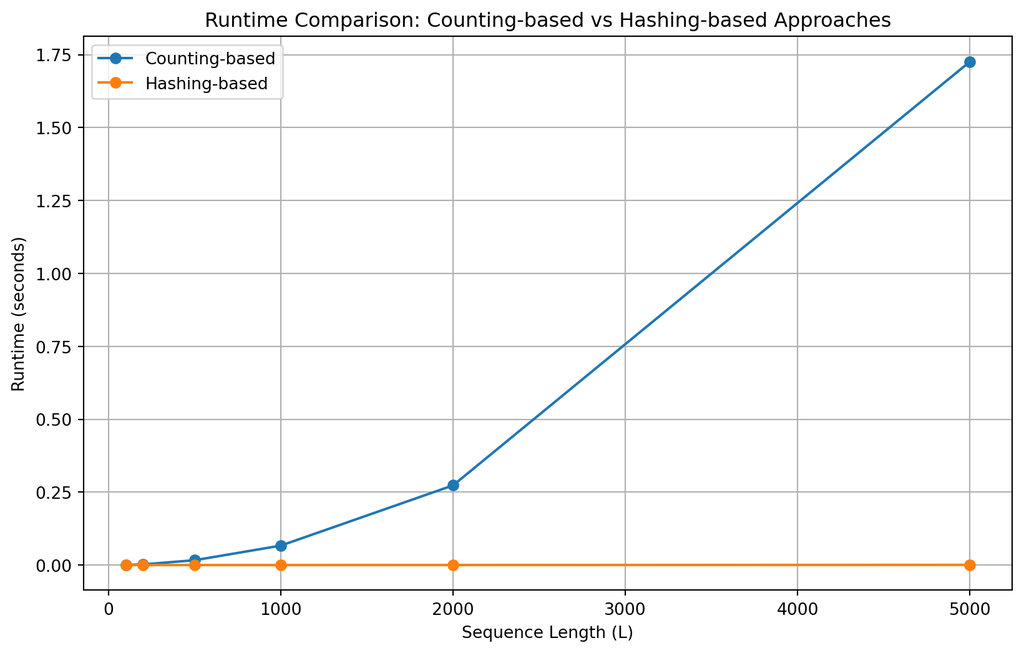

```python
import time
import numpy as np
import matplotlib.pyplot as plt

class BioinformaticsAlgorithms:

    # Method to count occurrences of a pattern in a given text
    def pattern_count(self, text, pattern):
        count = 0
        pattern_length = len(pattern)

        # Loop through the text and compare each substring with the pattern
        for i in range(len(text) - pattern_length + 1):
            if text[i:i + pattern_length] == pattern:
                count += 1

        return count

    # Method to find the most frequent k-mers (substrings of length k) in a given text by counting
    def frequent_words_by_counting(self, text, k):
        counts = {}

        # Loop through the text and calculate counts for each k-mer
        for i in range(len(text) - k + 1):
            pattern = text[i:i + k]
            counts[pattern] = self.pattern_count(text, pattern)

        # Find the maximum count
        max_count = max(counts.values())

        # Collect all patterns with the maximum count
        frequent_patterns = {pattern: count for pattern, count in counts.items() if count == max_count}

        return frequent_patterns

    # Method to create a frequency map (hash map) of k-mers in a given text
    def frequency_map(self, text, k):
        frequency_map = {}

        # Loop through the text and update the frequency map for each k-mer
        for i in range(len(text) - k + 1):
            pattern = text[i:i + k]

            # Update the count for the pattern in the map
            if pattern in frequency_map:
                frequency_map[pattern] += 1
            else:
                frequency_map[pattern] = 1

        return frequency_map

    # Method to find the most frequent k-mers (substrings of length k) in a given text using hashing
    def better_frequent_words(self, text, k):
        # Generate the frequency map
        frequency_map = self.frequency_map(text, k)

        # Find the maximum frequency
        max_count = max(frequency_map.values())

        # Collect all patterns with the maximum count
        frequent_patterns = {pattern: count for pattern, count in frequency_map.items() if count == max_count}

        return frequent_patterns

# Class to generate random DNA sequence
class DNAGenerator:

    def __init__(self):
        # Define probabilities for each nucleotide (A, C, G, T)
        self.probabilities = {"A": 0.25, "C": 0.25, "G": 0.25, "T": 0.25}
        self.nucleotides = list(self.probabilities.keys())
        self.probs = list(self.probabilities.values())

    def generate_dna_sequence(self, length):
        # Generate random DNA sequence of the given length using a multinomial distribution
        x = np.random.multinomial(1, self.probs, size=length)

        # Convert the multinomial result into a DNA sequence
        dna_sequence = ''.join(self.nucleotides[np.argmax(y)] for y in x)

        return dna_sequence
# Function to measure the runtime of both algorithms
def measure_runtime(sequence_length, k):
    bio_algo = BioinformaticsAlgorithms()
    dna_generator = DNAGenerator()
    text = dna_generator.generate_dna_sequence(sequence_length)

    # Measure runtime of frequent_words_by_counting (counting-based approach)
    start_time = time.time()
    bio_algo.frequent_words_by_counting(text, k)
    counting_time = time.time() - start_time

    # Measure runtime of better_frequent_words (hashing-based approach)
    start_time = time.time()
    bio_algo.better_frequent_words(text, k)
    hashing_time = time.time() - start_time

    return counting_time, hashing_time

# Test with various sequence lengths and k values
sequence_lengths = [100, 200, 500, 1000, 2000, 5000]
k = 5
counting_times = []
hashing_times = []

# Measure the runtime for both approaches
for length in sequence_lengths:
    counting_time, hashing_time = measure_runtime(length, k)
    counting_times.append(counting_time)
    hashing_times.append(hashing_time)

# Plot the results
plt.figure(figsize=(10, 6))
plt.plot(sequence_lengths, counting_times, label='Counting-based', marker='o')
plt.plot(sequence_lengths, hashing_times, label='Hashing-based', marker='o')
plt.xlabel('Sequence Length (L)')
plt.ylabel('Runtime (seconds)')
plt.title('Runtime Comparison: Counting-based vs Hashing-based Approaches')
plt.legend()
plt.grid(True)
```

## Frequent k-mers in the SARS-Cov-2 genome

### 5. Most Frequent k-mers in the SARS-CoV-2 Genome

We analyze the reference genome of SARS-CoV-2 to find the most frequent k-mers for different values of k (3, 6, 9, 12, 15).

```python
import numpy as np
from collections import Counter
import pandas as pd

# Bioinformatics Algorithms class with methods to find the most frequent k-mers
class BioinformaticsAlgorithms:

    # Method to create a frequency map (hash map) of k-mers in a given text
    def frequency_map(self, text, k):
        frequency_map = {}

        # Loop through the text and update the frequency map for each k-mer
        for i in range(len(text) - k + 1):
            pattern = text[i:i + k]

            # Update the count for the pattern in the map
            if pattern in frequency_map:
                frequency_map[pattern] += 1
            else:
                frequency_map[pattern] = 1

        return frequency_map

    # Method to find the most frequent k-mers (substrings of length k) in a given text using hashing
    def most_frequent_kmers(self, text, k):
        # Generate the frequency map
        frequency_map = self.frequency_map(text, k)

        # Find the maximum frequency
        max_count = max(frequency_map.values())

        # Collect all patterns with the maximum count
        most_frequent_kmers = [pattern for pattern, count in frequency_map.items() if count == max_count]

        return most_frequent_kmers, max_count

# SARS-CoV-2 genome sequence
genome_sequence = """
ATTAAAGGTTTATACCTTCCCAGGTAACAAACCAACCAACTTTCGATCTCTTGTAGATCTGTTCTCTAAA
CGAACTTTAAAATCTGTGTGGCTGTCACTCGGCTGCATGCTTAGTGCACTCACGCAGTATAATTAATAAC
TAATTACTGTCGTTGACAGGACACGAGTAACTCGTCTATCTTCTGCAGGCTGCTTACGGTTTCGTCCGTG
TTGCAGCCGATCATCAGCACATCTAGGTTTCGTCCGGGTGTGACCGAAAGGTAAGATGGAGAGCCTTGTC
CCTGGTTTCAACGAGAAAACACACGTCCAACTCAGTTTGCCTGTTTTACAGGTTCGCGACGTGCTCGTAC
GTGGCTTTGGAGACTCCGTGGAGGAGGTCTTATCAGAGGCACGTCAACATCTTAAAGATGGCACTTGTGG
CTTAGTAGAAGTTGAAAAAGGCGTTTTGCCTCAACTTGAACAGCCCTATGTGTTCATCAAACGTTCGGAT
GCTCGAACTGCACCTCATGGTCATGTTATGGTTGAGCTGGTAGCAGAACTCGAAGGCATTCAGTACGGTC
GTAGTGGTGAGACACTTGGTGTCCTTGTCCCTCATGTGGGCGAAATACCAGTGGCTTACCGCAAGGTTCT
TCTTCGTAAGAACGGTAATAAAGGAGCTGGTGGCCATAGTTACGGCGCCGATCTAAAGTCATTTGACTTA
GGCGACGAGCTTGGCACTGATCCTTATGAAGATTTTCAAGAAAACTGGAACACTAAACATAGCAGTGGTG
TTACCCGTGAACTCATGCGTGAGCTTAACGGAGGGGCATACACTCGCTATGTCGATAACAACTTCTGTGG
CCCTGATGGCTACCCTCTTGAGTGCATTAAAGACCTTCTAGCACGTGCTGGTAAAGCTTCATGCACTTTG
TCCGAACAACTGGACTTTATTGACACTAAGAGGGGTGTATACTGCTGCCGTGAACATGAGCATGAAATTG
CTTGGTACACGGAACGTTCTGAAAAGAGCTATGAATTGCAGACACCTTTTGAAATTAAATTGGCAAAGAA
ATTTGACACCTTCAATGGGGAATGTCCAAATTTTGTATTTCCCTTAAATTCCATAATCAAGACTATTCAA
CCAAGGGTTGAAAAGAAAAAGCTTGATGGCTTTATGGGTAGAATTCGATCTGTCTATCCAGTTGCGTCAC
CAAATGAATGCAACCAAATGTGCCTTTCAACTCTCATGAAGTGTGATCATTGTGGTGAAACTTCATGGCA
GACGGGCGATTTTGTTAAAGCCACTTGCGAATTTTGTGGCACTGAGAATTTGACTAAAGAAGGTGCCACT
ACTTGTGGTTACTTACCCCAAAATGCTGTTGTTAAAATTTATTGTCCAGCATGTCACAATTCAGAAGTAG
GACCTGAGCATAGTCTTGCCGAATACCATAATGAATCTGGCTTGAAAACCATTCTTCGTAAGGGTGGTCG
CACTATTGCCTTTGGAGGCTGTGTGTTCTCTTATGTTGGTTGCCATAACAAGTGTGCCTATTGGGTTCCA
CGTGCTAGCGCTAACATAGGTTGTAACCATACAGGTGTTGTTGGAGAAGGTTCCGAAGGTCTTAATGACA
ACCTTCTTGAAATACTCCAAAAAGAGAAAGTCAACATCAATATTGTTGGTGACTTTAAACTTAATGAAGA
GATCGCCATTATTTTGGCATCTTTTTCTGCTTCCACAAGTGCTTTTGTGGAAACTGTGAAAGGTTTGGAT
TATAAAGCATTCAAACAAATTGTTGAATCCTGTGGTAATTTTAAAGTTACAAAAGGAAAAGCTAAAAAAG
GTGCCTGGAATATTGGTGAACAGAAATCAATACTGAGTCCTCTTTATGCATTTGCATCAGAGGCTGCTCG
TGTTGTACGATCAATTTTCTCCCGCACTCTTGAAACTGCTCAAAATTCTGTGCGTGTTTTACAGAAGGCC
GCTATAACAATACTAGATGGAATTTCACAGTATTCACTGAGACTCATTGATGCTATGATGTTCACATCTG
ATTTGGCTACTAACAATCTAGTTGTAATGGCCTACATTACAGGTGGTGTTGTTCAGTTGACTTCGCAGTG
GCTAACTAACATCTTTGGCACTGTTTATGAAAAACTCAAACCCGTCCTTGATTGGCTTGAAGAGAAGTTT
AAGGAAGGTGTAGAGTTTCTTAGAGACGGTTGGGAAATTGTTAAATTTATCTCAACCTGTGCTTGTGAAA
TTGTCGGTGGACAAATTGTCACCTGTGCAAAGGAAATTAAGGAGAGTGTTCAGACATTCTTTAAGCTTGT
AAATAAATTTTTGGCTTTGTGTGCTGACTCTATCATTATTGGTGGAGCTAAACTTAAAGCCTTGAATTTA
GGTGAAACATTTGTCACGCACTCAAAGGGATTGTACAGAAAGTGTGTTAAATCCAGAGAAGAAACTGGCC
TACTCATGCCTCTAAAAGCCCCAAAAGAAATTATCTTCTTAGAGGGAGAAACACTTCCCACAGAAGTGTT
AACAGAGGAAGTTGTCTTGAAAACTGGTGATTTACAACCATTAGAACAACCTACTAGTGAAGCTGTTGAA
GCTCCATTGGTTGGTACACCAGTTTGTATTAACGGGCTTATGTTGCTCGAAATCAAAGACACAGAAAAGT
ACTGTGCCCTTGCACCTAATATGATGGTAACAAACAATACCTTCACACTCAAAGGCGGTGCACCAACAAA
GGTTACTTTTGGTGATGACACTGTGATAGAAGTGCAAGGTTACAAGAGTGTGAATATCACTTTTGAACTT
GATGAAAGGATTGATAAAGTACTTAATGAGAAGTGCTCTGCCTATACAGTTGAACTCGGTACAGAAGTAA
ATGAGTTCGCCTGTGTTGTGGCAGATGCTGTCATAAAAACTTTGCAACCAGTATCTGAATTACTTACACC
ACTGGGCATTGATTTAGATGAGTGGAGTATGGCTACATACTACTTATTTGATGAGTCTGGTGAGTTTAAA
TTGGCTTCACATATGTATTGTTCTTTCTACCCTCCAGATGAGGATGAAGAAGAAGGTGATTGTGAAGAAG
AAGAGTTTGAGCCATCAACTCAATATGAGTATGGTACTGAAGATGATTACCAAGGTAAACCTTTGGAATT
TGGTGCCACTTCTGCTGCTCTTCAACCTGAAGAAGAGCAAGAAGAAGATTGGTTAGATGATGATAGTCAA
CAAACTGTTGGTCAACAAGACGGCAGTGAGGACAATCAGACAACTACTATTCAAACAATTGTTGAGGTTC
AACCTCAATTAGAGATGGAACTTACACCAGTTGTTCAGACTATTGAAGTGAATAGTTTTAGTGGTTATTT
AAAACTTACTGACAATGTATACATTAAAAATGCAGACATTGTGGAAGAAGCTAAAAAGGTAAAACCAACA
GTGGTTGTTAATGCAGCCAATGTTTACCTTAAACATGGAGGAGGTGTTGCAGGAGCCTTAAATAAGGCTA
CTAACAATGCCATGCAAGTTGAATCTGATGATTACATAGCTACTAATGGACCACTTAAAGTGGGTGGTAG
TTGTGTTTTAAGCGGACACAATCTTGCTAAACACTGTCTTCATGTTGTCGGCCCAAATGTTAACAAAGGT
GAAGACATTCAACTTCTTAAGAGTGCTTATGAAAATTTTAATCAGCACGAAGTTCTACTTGCACCATTAT
TATCAGCTGGTATTTTTGGTGCTGACCCTATACATTCTTTAAGAGTTTGTGTAGATACTGTTCGCACAAA
TGTCTACTTAGCTGTCTTTGATAAAAATCTCTATGACAAACTTGTTTCAAGCTTTTTGGAAATGAAGAGT
GAAAAGCAAGTTGAACAAAAGATCGCTGAGATTCCTAAAGAGGAAGTTAAGCCATTTATAACTGAAAGTA
AACCTTCAGTTGAACAGAGAAAACAAGATGATAAGAAAATCAAAGCTTGTGTTGAAGAAGTTACAACAAC
TCTGGAAGAAACTAAGTTCCTCACAGAAAACTTGTTACTTTATATTGACATTAATGGCAATCTTCATCCA
GATTCTGCCACTCTTGTTAGTGACATTGACATCACTTTCTTAAAGAAAGATGCTCCATATATAGTGGGTG
ATGTTGTTCAAGAGGGTGTTTTAACTGCTGTGGTTATACCTACTAAAAAGGCTGGTGGCACTACTGAAAT
GCTAGCGAAAGCTTTGAGAAAAGTGCCAACAGACAATTATATAACCACTTACCCGGGTCAGGGTTTAAAT
GGTTACACTGTAGAGGAGGCAAAGACAGTGCTTAAAAAGTGTAAAAGTGCCTTTTACATTCTACCATCTA
TTATCTCTAATGAGAAGCAAGAAATTCTTGGAACTGTTTCTTGGAATTTGCGAGAAATGCTTGCACATGC
AGAAGAAACACGCAAATTAATGCCTGTCTGTGTGGAAACTAAAGCCATAGTTTCAACTATACAGCGTAAA
TATAAGGGTATTAAAATACAAGAGGGTGTGGTTGATTATGGTGCTAGATTTTACTTTTACACCAGTAAAA
CAACTGTAGCGTCACTTATCAACACACTTAACGATCTAAATGAAACTCTTGTTACAATGCCACTTGGCTA
TGTAACACATGGCTTAAATTTGGAAGAAGCTGCTCGGTATATGAGATCTCTCAAAGTGCCAGCTACAGTT
TCTGTTTCTTCACCTGATGCTGTTACAGCGTATAATGGTTATCTTACTTCTTCTTCTAAAACACCTGAAG
AACATTTTATTGAAACCATCTCACTTGCTGGTTCCTATAAAGATTGGTCCTATTCTGGACAATCTACACA
ACTAGGTATAGAATTTCTTAAGAGAGGTGATAAAAGTGTATATTACACTAGTAATCCTACCACATTCCAC
CTAGATGGTGAAGTTATCACCTTTGACAATCTTAAGACACTTCTTTCTTTGAGAGAAGTGAGGACTATTA
AGGTGTTTACAACAGTAGACAACATTAACCTCCACACGCAAGTTGTGGACATGTCAATGACATATGGACA
ACAGTTTGGTCCAACTTATTTGGATGGAGCTGATGTTACTAAAATAAAACCTCATAATTCACATGAAGGT
AAAACATTTTATGTTTTACCTAATGATGACACTCTACGTGTTGAGGCTTTTGAGTACTACCACACAACTG
ATCCTAGTTTTCTGGGTAGGTACATGTCAGCATTAAATCACACTAAAAAGTGGAAATACCCACAAGTTAA
TGGTTTAACTTCTATTAAATGGGCAGATAACAACTGTTATCTTGCCACTGCATTGTTAACACTCCAACAA
ATAGAGTTGAAGTTTAATCCACCTGCTCTACAAGATGCTTATTACAGAGCAAGGGCTGGTGAAGCTGCTA
ACTTTTGTGCACTTATCTTAGCCTACTGTAATAAGACAGTAGGTGAGTTAGGTGATGTTAGAGAAACAAT
GAGTTACTTGTTTCAACATGCCAATTTAGATTCTTGCAAAAGAGTCTTGAACGTGGTGTGTAAAACTTGT
GGACAACAGCAGACAACCCTTAAGGGTGTAGAAGCTGTTATGTACATGGGCACACTTTCTTATGAACAAT
TTAAGAAAGGTGTTCAGATACCTTGTACGTGTGGTAAACAAGCTACAAAATATCTAGTACAACAGGAGTC
ACCTTTTGTTATGATGTCAGCACCACCTGCTCAGTATGAACTTAAGCATGGTACATTTACTTGTGCTAGT
GAGTACACTGGTAATTACCAGTGTGGTCACTATAAACATATAACTTCTAAAGAAACTTTGTATTGCATAG
ACGGTGCTTTACTTACAAAGTCCTCAGAATACAAAGGTCCTATTACGGATGTTTTCTACAAAGAAAACAG
TTACACAACAACCATAAAACCAGTTACTTATAAATTGGATGGTGTTGTTTGTACAGAAATTGACCCTAAG
TTGGACAATTATTATAAGAAAGACAATTCTTATTTCACAGAGCAACCAATTGATCTTGTACCAAACCAAC
CATATCCAAACGCAAGCTTCGATAATTTTAAGTTTGTATGTGATAATATCAAATTTGCTGATGATTTAAA
CCAGTTAACTGGTTATAAGAAACCTGCTTCAAGAGAGCTTAAAGTTACATTTTTCCCTGACTTAAATGGT
GATGTGGTGGCTATTGATTATAAACACTACACACCCTCTTTTAAGAAAGGAGCTAAATTGTTACATAAAC
CTATTGTTTGGCATGTTAACAATGCAACTAATAAAGCCACGTATAAACCAAATACCTGGTGTATACGTTG
TCTTTGGAGCACAAAACCAGTTGAAACATCAAATTCGTTTGATGTACTGAAGTCAGAGGACGCGCAGGGA
ATGGATAATCTTGCCTGCGAAGATCTAAAACCAGTCTCTGAAGAAGTAGTGGAAAATCCTACCATACAGA
AAGACGTTCTTGAGTGTAATGTGAAAACTACCGAAGTTGTAGGAGACATTATACTTAAACCAGCAAATAA
TAGTTTAAAAATTACAGAAGAGGTTGGCCACACAGATCTAATGGCTGCTTATGTAGACAATTCTAGTCTT
ACTATTAAGAAACCTAATGAATTATCTAGAGTATTAGGTTTGAAAACCCTTGCTACTCATGGTTTAGCTG
CTGTTAATAGTGTCCCTTGGGATACTATAGCTAATTATGCTAAGCCTTTTCTTAACAAAGTTGTTAGTAC
AACTACTAACATAGTTACACGGTGTTTAAACCGTGTTTGTACTAATTATATGCCTTATTTCTTTACTTTA
TTGCTACAATTGTGTACTTTTACTAGAAGTACAAATTCTAGAATTAAAGCATCTATGCCGACTACTATAG
CAAAGAATACTGTTAAGAGTGTCGGTAAATTTTGTCTAGAGGCTTCATTTAATTATTTGAAGTCACCTAA
TTTTTCTAAACTGATAAATATTATAATTTGGTTTTTACTATTAAGTGTTTGCCTAGGTTCTTTAATCTAC
TCAACCGCTGCTTTAGGTGTTTTAATGTCTAATTTAGGCATGCCTTCTTACTGTACTGGTTACAGAGAAG
GCTATTTGAACTCTACTAATGTCACTATTGCAACCTACTGTACTGGTTCTATACCTTGTAGTGTTTGTCT
TAGTGGTTTAGATTCTTTAGACACCTATCCTTCTTTAGAAACTATACAAATTACCATTTCATCTTTTAAA
TGGGATTTAACTGCTTTTGGCTTAGTTGCAGAGTGGTTTTTGGCATATATTCTTTTCACTAGGTTTTTCT
ATGTACTTGGATTGGCTGCAATCATGCAATTGTTTTTCAGCTATTTTGCAGTACATTTTATTAGTAATTC
TTGGCTTATGTGGTTAATAATTAATCTTGTACAAATGGCCCCGATTTCAGCTATGGTTAGAATGTACATC
TTCTTTGCATCATTTTATTATGTATGGAAAAGTTATGTGCATGTTGTAGACGGTTGTAATTCATCAACTT
GTATGATGTGTTACAAACGTAATAGAGCAACAAGAGTCGAATGTACAACTATTGTTAATGGTGTTAGAAG
GTCCTTTTATGTCTATGCTAATGGAGGTAAAGGCTTTTGCAAACTACACAATTGGAATTGTGTTAATTGT
GATACATTCTGTGCTGGTAGTACATTTATTAGTGATGAAGTTGCGAGAGACTTGTCACTACAGTTTAAAA
GACCAATAAATCCTACTGACCAGTCTTCTTACATCGTTGATAGTGTTACAGTGAAGAATGGTTCCATCCA
TCTTTACTTTGATAAAGCTGGTCAAAAGACTTATGAAAGACATTCTCTCTCTCATTTTGTTAACTTAGAC
AACCTGAGAGCTAATAACACTAAAGGTTCATTGCCTATTAATGTTATAGTTTTTGATGGTAAATCAAAAT
GTGAAGAATCATCTGCAAAATCAGCGTCTGTTTACTACAGTCAGCTTATGTGTCAACCTATACTGTTACT
AGATCAGGCATTAGTGTCTGATGTTGGTGATAGTGCGGAAGTTGCAGTTAAAATGTTTGATGCTTACGTT
AATACGTTTTCATCAACTTTTAACGTACCAATGGAAAAACTCAAAACACTAGTTGCAACTGCAGAAGCTG
AACTTGCAAAGAATGTGTCCTTAGACAATGTCTTATCTACTTTTATTTCAGCAGCTCGGCAAGGGTTTGT
TGATTCAGATGTAGAAACTAAAGATGTTGTTGAATGTCTTAAATTGTCACATCAATCTGACATAGAAGTT
ACTGGCGATAGTTGTAATAACTATATGCTCACCTATAACAAAGTTGAAAACATGACACCCCGTGACCTTG
GTGCTTGTATTGACTGTAGTGCGCGTCATATTAATGCGCAGGTAGCAAAAAGTCACAACATTGCTTTGAT
ATGGAACGTTAAAGATTTCATGTCATTGTCTGAACAACTACGAAAACAAATACGTAGTGCTGCTAAAAAG
AATAACTTACCTTTTAAGTTGACATGTGCAACTACTAGACAAGTTGTTAATGTTGTAACAACAAAGATAG
CACTTAAGGGTGGTAAAATTGTTAATAATTGGTTGAAGCAGTTAATTAAAGTTACACTTGTGTTCCTTTT
TGTTGCTGCTATTTTCTATTTAATAACACCTGTTCATGTCATGTCTAAACATACTGACTTTTCAAGTGAA
ATCATAGGATACAAGGCTATTGATGGTGGTGTCACTCGTGACATAGCATCTACAGATACTTGTTTTGCTA
ACAAACATGCTGATTTTGACACATGGTTTAGCCAGCGTGGTGGTAGTTATACTAATGACAAAGCTTGCCC
ATTGATTGCTGCAGTCATAACAAGAGAAGTGGGTTTTGTCGTGCCTGGTTTGCCTGGCACGATATTACGC
ACAACTAATGGTGACTTTTTGCATTTCTTACCTAGAGTTTTTAGTGCAGTTGGTAACATCTGTTACACAC
CATCAAAACTTATAGAGTACACTGACTTTGCAACATCAGCTTGTGTTTTGGCTGCTGAATGTACAATTTT
TAAAGATGCTTCTGGTAAGCCAGTACCATATTGTTATGATACCAATGTACTAGAAGGTTCTGTTGCTTAT
GAAAGTTTACGCCCTGACACACGTTATGTGCTCATGGATGGCTCTATTATTCAATTTCCTAACACCTACC
TTGAAGGTTCTGTTAGAGTGGTAACAACTTTTGATTCTGAGTACTGTAGGCACGGCACTTGTGAAAGATC
AGAAGCTGGTGTTTGTGTATCTACTAGTGGTAGATGGGTACTTAACAATGATTATTACAGATCTTTACCA
GGAGTTTTCTGTGGTGTAGATGCTGTAAATTTACTTACTAATATGTTTACACCACTAATTCAACCTATTG
GTGCTTTGGACATATCAGCATCTATAGTAGCTGGTGGTATTGTAGCTATCGTAGTAACATGCCTTGCCTA
CTATTTTATGAGGTTTAGAAGAGCTTTTGGTGAATACAGTCATGTAGTTGCCTTTAATACTTTACTATTC
CTTATGTCATTCACTGTACTCTGTTTAACACCAGTTTACTCATTCTTACCTGGTGTTTATTCTGTTATTT
ACTTGTACTTGACATTTTATCTTACTAATGATGTTTCTTTTTTAGCACATATTCAGTGGATGGTTATGTT
CACACCTTTAGTACCTTTCTGGATAACAATTGCTTATATCATTTGTATTTCCACAAAGCATTTCTATTGG
TTCTTTAGTAATTACCTAAAGAGACGTGTAGTCTTTAATGGTGTTTCCTTTAGTACTTTTGAAGAAGCTG
CGCTGTGCACCTTTTTGTTAAATAAAGAAATGTATCTAAAGTTGCGTAGTGATGTGCTATTACCTCTTAC
GCAATATAATAGATACTTAGCTCTTTATAATAAGTACAAGTATTTTAGTGGAGCAATGGATACAACTAGC
TACAGAGAAGCTGCTTGTTGTCATCTCGCAAAGGCTCTCAATGACTTCAGTAACTCAGGTTCTGATGTTC
TTTACCAACCACCACAAACCTCTATCACCTCAGCTGTTTTGCAGAGTGGTTTTAGAAAAATGGCATTCCC
ATCTGGTAAAGTTGAGGGTTGTATGGTACAAGTAACTTGTGGTACAACTACACTTAACGGTCTTTGGCTT
GATGACGTAGTTTACTGTCCAAGACATGTGATCTGCACCTCTGAAGACATGCTTAACCCTAATTATGAAG
ATTTACTCATTCGTAAGTCTAATCATAATTTCTTGGTACAGGCTGGTAATGTTCAACTCAGGGTTATTGG
ACATTCTATGCAAAATTGTGTACTTAAGCTTAAGGTTGATACAGCCAATCCTAAGACACCTAAGTATAAG
TTTGTTCGCATTCAACCAGGACAGACTTTTTCAGTGTTAGCTTGTTACAATGGTTCACCATCTGGTGTTT
ACCAATGTGCTATGAGGCCCAATTTCACTATTAAGGGTTCATTCCTTAATGGTTCATGTGGTAGTGTTGG
TTTTAACATAGATTATGACTGTGTCTCTTTTTGTTACATGCACCATATGGAATTACCAACTGGAGTTCAT
```